# Simulate and tune a two-group AI evaluation

Questions, repeated calls, and blocking with DeclareDesign

We want to know whether **retrieval improves the score of a model’s answers**. Start with two groups of questions: retrieval off and retrieval on. Then change one design decision at a time:

1. How many independent questions do we evaluate?
2. With a fixed budget, should we buy more questions or more calls per question?
3. Should we block similar questions before randomizing? How small should the blocks be?
4. How sensitive are the answers to our assumed effect and measurement noise?

Every simulated call gets its own score. We inspect these individual records before averaging anything. The **four-condition factorial** and the **annotation reliability model** are optional bonus sections.

Run the chunks in order, or render the document:

```bash
quarto render factorial-design-tuning.qmd
# Faster check:
quarto render factorial-design-tuning.qmd -P simulations:100
```

Install once: `install.packages(c("DeclareDesign", "rmarkdown", "ggplot2"))`. The design code is self-contained and makes no model API calls. Keep `plot-style.R` and `demo-style.scss` alongside this file for the lecture styling. For rendering charts, also install `ragg` and `systemfonts`.

```r
library(DeclareDesign)
library(ggplot2)
sims <- params$simulations
stopifnot(sims >= 100)
set.seed(20260929)
```

## 1 Start with two groups and one estimand

| Group | Bundle | What gets scored? |
| --- | --- | --- |
| Z = 0 | Retrieval off | Model answers to the assigned questions |
| Z = 1 | Retrieval on | Model answers to the assigned questions |

Hold the model, instruction, decoding, and scoring rule fixed. Each question receives **one** Bundle, and all repeated calls for that question use that same Bundle, in fresh contexts. Half of the questions go to each group.

The estimand is the **average retrieval effect in score points across the target population of questions and repeated calls**. We assume a constant 3-point effect to start. With a constant effect, the population and sample effects agree.

This is a between-question design. The lecture also showed pairing, where both Bundles answer every question. Here the simpler two-group design lets us see what randomization and blocking do; it is not a claim that we should discard pairing when both conditions can be evaluated cleanly on each question.

## 2 Draw questions, then draw individual calls

For question i and call j, our first planning model is

$$Y_{ij}(z)=50+a_i+\tau z+\epsilon_{ij}.$$

- $a_i$: question-level variation shared by its repeated calls.
- $\epsilon_{ij}$: individual generation and scoring noise.
- $\tau$: retrieval’s effect, in points.

A pretreatment score `pretest` helps predict question difficulty. It could come from a pilot or a human difficulty rating. It must be available **before** assignment. `predictiveness` is its population R-squared for $a_i$, not the R-squared of the final block indicators or of noisy individual call scores.

```r
n_questions <- 120
repeats <- 2                 # calls for each question's assigned Bundle
tau <- 3                    # effect in score points
sd_question <- 8            # differences across questions
sd_call <- 10               # noise in ONE call's score
predictiveness <- .6
block_size <- 10            # questions per block, used later
use_blocks <- FALSE
```

`add_level()` first draws the questions, then expands each into `repeats` call records. Variables drawn at the question level are copied to its calls. `rnorm(N, sd = sd_call)` is evaluated at the **call level**: no simulated means or standard errors are substituted for the individual draws.

```r
model <- declare_model(
  questions = add_level(
    N = n_questions,
    pretest = rnorm(N),
    a = sd_question * (sqrt(predictiveness) * pretest +
                        sqrt(1 - predictiveness) * rnorm(N)),
    block = ceiling(rank(pretest, ties.method = "first") / block_size)
  ),
  calls = add_level(
    N = repeats,
    noise = rnorm(N, sd = sd_call),
    potential_outcomes(Y ~ 50 + a + tau * Z + noise)
  )
)
set.seed(6201)
potential_data <- model()
knitr::kable(head(potential_data[, c("questions", "calls", "pretest", "a",
                                    "noise", "Y_Z_0", "Y_Z_1")]), digits = 2)
```

| questions | calls | pretest | a | noise | Y_Z_0 | Y_Z_1 |
| --- | --- | --- | --- | --- | --- | --- |
| 001 | 001 | -0.18 | -12.60 | -12.13 | 25.26 | 28.26 |
| 001 | 002 | -0.18 | -12.60 | -0.46 | 36.94 | 39.94 |
| 002 | 003 | -0.14 | -9.41 | 7.49 | 48.08 | 51.08 |
| 002 | 004 | -0.14 | -9.41 | -13.79 | 26.80 | 29.80 |
| 003 | 005 | -0.33 | -3.97 | 7.18 | 53.21 | 56.21 |
| 003 | 006 | -0.33 | -3.97 | 4.90 | 50.93 | 53.93 |

Two rows with the same `questions` ID share `a`, but have different `noise` draws. `Y_Z_0` and `Y_Z_1` are the simulated potential scores for that call. Only one will be observed. Their shared noise imposes a constant-effect model; it does not mean we would reuse a real API response under the alternative condition.

Scores are a Gaussian approximation to a rubric scored in points, centered at 50. They are not constrained to 0–100. The annotation bonus separates response quality from rating error. These variances and effects are assumptions to explore, not facts about an actual model.

## 3 Assign questions and reveal their observed scores

The assignment unit is the question. In the expanded data, repeated calls are clustered within that question, so `cluster_ra()` gives them one common assignment. When `use_blocks` becomes true, we randomize questions within their pretest blocks.

```r
inquiry <- declare_inquiry(ATE = tau)
assignment <- declare_assignment(
  Z = if (use_blocks) {
    block_and_cluster_ra(blocks = block, clusters = questions, prob = .5)
  } else {
    cluster_ra(clusters = questions, prob = .5)
  }
)
measurement <- declare_measurement(Y = reveal_outcomes(Y ~ Z))
data_design <- model + inquiry + assignment + measurement

set.seed(6202)
one_study <- draw_data(data_design)
knitr::kable(head(one_study[, c("questions", "calls", "block", "Z", "Y")]),
             digits = 2)
```

| questions | calls | block | Z | Y |
| --- | --- | --- | --- | --- |
| 001 | 001 | 3 | 1 | 46.45 |
| 001 | 002 | 3 | 1 | 47.34 |
| 002 | 003 | 8 | 0 | 70.85 |
| 002 | 004 | 8 | 0 | 75.81 |
| 003 | 005 | 3 | 1 | 37.68 |
| 003 | 006 | 3 | 1 | 50.88 |

```r
question_assignments <- unique(one_study[, c("questions", "Z")])
knitr::kable(as.data.frame(table(question_assignments$Z)),
             col.names = c("Retrieval assignment", "Questions"))
```

| Retrieval assignment | Questions |
| --- | --- |
| 0 | 60 |
| 1 | 60 |

We have 120 questions and 240 observed calls. Those are not 240 independent questions.

## 4 Analyze the same data we just drew

Now average calls within each question. This is an **analysis step after drawing individual scores**. Questions, not calls, are the independent units used to estimate uncertainty.

```r
question_means <- aggregate(cbind(Y, Z, block) ~ questions,
                            data = one_study, FUN = mean)
knitr::kable(head(question_means), digits = 2)
```

| questions | Y | Z | block |
| --- | --- | --- | --- |
| 001 | 46.90 | 1 | 3 |
| 002 | 73.33 | 0 | 8 |
| 003 | 44.28 | 1 | 3 |
| 004 | 47.32 | 1 | 10 |
| 005 | 50.45 | 1 | 3 |
| 006 | 46.16 | 0 | 1 |

```r
first_answer <- difference_in_means(Y ~ Z, data = question_means)
knitr::kable(tidy(first_answer), digits = 3)
```

| term | estimate | std.error | statistic | p.value | conf.low | conf.high | df | outcome |
| --- | --- | --- | --- | --- | --- | --- | --- | --- |
| Z | 4.009 | 2.19 | 1.831 | 0.07 | -0.328 | 8.346 | 117.993 | Y |

For the blocked design, estimate a difference within each block and average those differences with block-size weights. `difference_in_means()` implements that estimator and its design-appropriate standard error when supplied `blocks`. The same question-averaging step applies to both assignments.

```r
analyze_questions <- function(data, use_blocks = FALSE) {
  q <- aggregate(cbind(Y, Z, block) ~ questions, data = data, FUN = mean)
  fit <- if (use_blocks) {
    difference_in_means(Y ~ Z, blocks = block, data = q)
  } else {
    difference_in_means(Y ~ Z, data = q)
  }
  tidy(fit)
}
estimator <- declare_estimator(
  handler = label_estimator(analyze_questions),
  use_blocks = use_blocks, inquiry = "ATE"
)
design <- data_design + estimator
# Apply this declaration to the SAME call records above.
knitr::kable(estimator(one_study), digits = 3)
```

| estimator | term | estimate | std.error | statistic | p.value | conf.low | conf.high | df | outcome | inquiry |
| --- | --- | --- | --- | --- | --- | --- | --- | --- | --- | --- |
| estimator | Z | 4.009 | 2.19 | 1.831 | 0.07 | -0.328 | 8.346 | 117.993 | Y | ATE |

## 5 Repeat the study to estimate power

Each repetition draws new questions and calls, randomizes the questions, and analyzes the observed scores. Power is the fraction of two-sided tests with p < .05 when the assumed effect is nonzero. Coverage asks how often the 95% interval contains the true effect.

```r
checks <- declare_diagnosands(
  bias = mean(estimate - estimand),
  sd_estimate = sd(estimate),
  mean_se = mean(std.error),
  power = mean(p.value < .05),
  coverage = mean(conf.low <= estimand & conf.high >= estimand),
  mcse_power = sqrt(mean(p.value < .05) * (1 - mean(p.value < .05)) /
                      length(p.value))
)
set.seed(6203)
baseline_diagnosis <- diagnose_design(design, sims = sims,
  diagnosands = checks, bootstrap_sims = FALSE)
baseline <- get_diagnosands(baseline_diagnosis)
knitr::kable(baseline[, c("bias", "sd_estimate", "mean_se", "power",
                         "coverage", "mcse_power")], digits = 3)
```

| bias | sd_estimate | mean_se | power | coverage | mcse_power |
| --- | --- | --- | --- | --- | --- |
| -0.085 | 1.938 | 1.938 | 0.34 | 0.954 | 0.021 |

`mcse_power` is uncertainty from running a finite number of simulations. It is separate from uncertainty about the assumed effect or score model. A precise power estimate under a poor assumption can still mislead.

## 6 Decision 1: evaluate more questions

Keep calls per question and the score model fixed. `redesign()` changes the parameters used by the declarations; here it gives three sample sizes. These alternatives have different costs.

```r
question_designs <- redesign(design, n_questions = c(60, 120, 240))
set.seed(6204)
question_diagnosis <- diagnose_design(question_designs, sims = sims,
  diagnosands = checks, bootstrap_sims = FALSE)
question_results <- get_diagnosands(question_diagnosis)
knitr::kable(question_results[, c("n_questions", "power", "mcse_power",
                                 "sd_estimate", "coverage")], digits = 3)
```

| n_questions | power | mcse_power | sd_estimate | coverage |
| --- | --- | --- | --- | --- |
| 60 | 0.174 | 0.017 | 2.762 | 0.956 |
| 120 | 0.344 | 0.021 | 2.074 | 0.954 |
| 240 | 0.570 | 0.022 | 1.434 | 0.932 |

More independent questions reduce uncertainty from both question differences and call noise. Merely increasing repeated calls cannot remove question-level variation from a between-question comparison.

## 7 Decision 2: more questions or more calls on a fixed budget?

Each question costs 10 units to prepare. Each scored call costs 1. A question gets only its assigned Bundle, so the cost is

$$C=I(10+R).$$

There is no factor of two here: unlike the paired example in the slides, we observe **one Bundle per question**. We choose the largest even number of questions affordable with 1,200 units so the two groups stay equally sized.

```r
allocations <- data.frame(repeats = c(1, 2, 5, 10))
allocations$n_questions <- 2 * floor(1200 / (10 + allocations$repeats) / 2)
allocations$cost <- with(allocations, n_questions * (10 + repeats))
knitr::kable(allocations, row.names = FALSE)
```

| repeats | n_questions | cost |
| --- | --- | --- |
| 1 | 108 | 1188 |
| 2 | 100 | 1200 |
| 5 | 80 | 1200 |
| 10 | 60 | 1200 |

```r
budget_designs <- redesign(design,
  n_questions = allocations$n_questions, repeats = allocations$repeats,
  expand = FALSE
)
set.seed(6205)
budget_diagnosis <- diagnose_design(budget_designs, sims = sims,
  diagnosands = checks, bootstrap_sims = FALSE)
budget_results <- get_diagnosands(budget_diagnosis)
```

`expand = FALSE` keeps each question count paired with its repeat count. Otherwise, `redesign()` would cross every count with every repeat count, including unaffordable combinations.

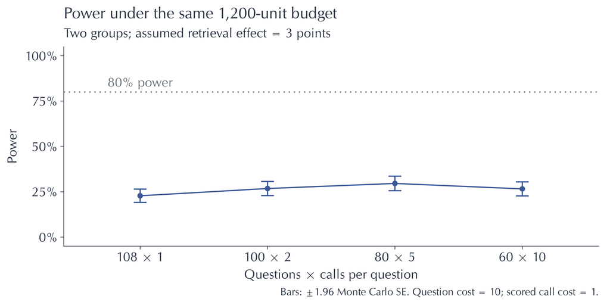

```r
budget_results$allocation <- factor(
  paste(budget_results$n_questions, "×", budget_results$repeats),
  levels = paste(allocations$n_questions, "×", allocations$repeats)
)
ggplot(budget_results, aes(allocation, power, group = 1)) +
  geom_hline(yintercept = .8, linetype = 3, colour = "#6c757d") +
  annotate("text", x = 1, y = .8, label = "80% power", vjust = -.6,
           family = "URWClassico", colour = "#6c757d") +
  geom_line(colour = "#3b5998") + geom_point(colour = "#3b5998") +
  geom_errorbar(aes(ymin = pmax(0, power - 1.96 * mcse_power),
                    ymax = pmin(1, power + 1.96 * mcse_power)), width = .1, colour = "#3b5998") +
  scale_x_discrete() +
  scale_y_continuous(limits = c(0, 1), labels = scales::label_percent()) +
  labs(x = "Questions × calls per question", y = "Power",
       title = "Power under the same 1,200-unit budget",
       subtitle = "Two groups; assumed retrieval effect = 3 points",
       caption = "Bars: ±1.96 Monte Carlo SE. Question cost = 10; scored call cost = 1.")
```

Under this model, the approximate variance is

$$V(\hat\tau)=\frac{4}{I}\left(\sigma_{\text{question}}^2+
\frac{\sigma_{\text{call}}^2}{R}\right).$$

More calls reduce the second term, but leave fewer questions to average the first. Look at the achievable power as well as which allocation is best: the best of these alternatives may still be inadequate for a 3-point effect. Small differences inside the Monte Carlo bars should not drive the decision.

## 8 Decision 3: block similar questions before assignment

Sort questions by their pretreatment score, divide adjacent questions into blocks, and randomize half to each Bundle **within each block**. A block size of 4 means 30 blocks in a 120-question study; a size of 20 means 6 blocks. All sizes here are even and divide the number of questions exactly.

```r
blocked_design <- redesign(design, use_blocks = TRUE, block_size = 10)
set.seed(6206)
blocked_calls <- draw_data(blocked_design)
blocked_questions <- unique(blocked_calls[, c("questions", "block", "Z")])
knitr::kable(with(blocked_questions, table(block, Z)))
```

| 0 | 1 |
| --- | --- |
| 5 | 5 |
| 5 | 5 |
| 5 | 5 |
| 5 | 5 |
| 5 | 5 |
| 5 | 5 |
| 5 | 5 |
| 5 | 5 |
| 5 | 5 |
| 5 | 5 |
| 5 | 5 |
| 5 | 5 |

Repeat this comparison when the pretreatment score is useless or strongly predictive. We hold the marginal variance of question difficulty fixed while changing how much the pretest explains. `use_blocks` changes **both assignment and analysis** in our declaration.

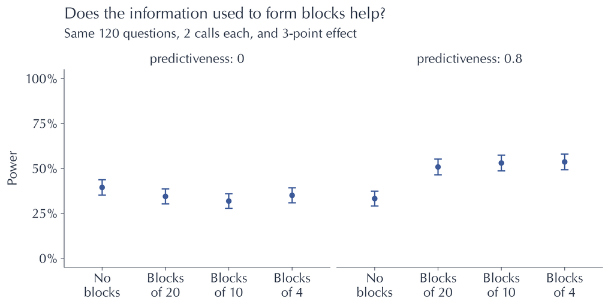

```r
blocking_grid <- expand.grid(
  block_size = c(4, 10, 20), predictiveness = c(0, .8)
)
blocking_grid$use_blocks <- TRUE
blocking_grid <- rbind(
  data.frame(block_size = 10, predictiveness = c(0, .8), use_blocks = FALSE),
  blocking_grid
)
blocking_designs <- redesign(design,
  block_size = blocking_grid$block_size,
  predictiveness = blocking_grid$predictiveness,
  use_blocks = blocking_grid$use_blocks, expand = FALSE
)
set.seed(6207)
blocking_diagnosis <- diagnose_design(blocking_designs, sims = sims,
  diagnosands = checks, bootstrap_sims = FALSE)
blocking_results <- get_diagnosands(blocking_diagnosis)
blocking_results$assignment <- ifelse(blocking_results$use_blocks,
  paste("Blocks of", blocking_results$block_size), "No blocks")
blocking_results$assignment <- factor(blocking_results$assignment,
  levels = c("No blocks", "Blocks of 20", "Blocks of 10", "Blocks of 4"))
ggplot(blocking_results, aes(assignment, power)) +
  geom_point(colour = "#3b5998") +
  geom_errorbar(aes(ymin = pmax(0, power - 1.96 * mcse_power),
                    ymax = pmin(1, power + 1.96 * mcse_power)), width = .12, colour = "#3b5998") +
  facet_wrap(~predictiveness, labeller = label_both) +
  scale_x_discrete(labels = c("No\nblocks", "Blocks\nof 20",
                              "Blocks\nof 10", "Blocks\nof 4")) +
  scale_y_continuous(limits = c(0, 1), labels = scales::label_percent()) +
  labs(x = NULL, y = "Power", title = "Does the information used to form blocks help?",
       subtitle = "Same 120 questions, 2 calls each, and 3-point effect")
```

```r
knitr::kable(blocking_results[, c("predictiveness", "assignment", "bias",
                                 "sd_estimate", "power", "coverage")], digits = 3)
```

| predictiveness | assignment | bias | sd_estimate | power | coverage |
| --- | --- | --- | --- | --- | --- |
| 0.0 | No blocks | 0.172 | 2.010 | 0.394 | 0.932 |
| 0.8 | No blocks | -0.040 | 1.936 | 0.332 | 0.948 |
| 0.0 | Blocks of 4 | 0.008 | 1.984 | 0.350 | 0.944 |
| 0.0 | Blocks of 10 | -0.042 | 1.888 | 0.318 | 0.964 |
| 0.0 | Blocks of 20 | 0.052 | 2.040 | 0.344 | 0.952 |
| 0.8 | Blocks of 4 | 0.031 | 1.442 | 0.536 | 0.946 |
| 0.8 | Blocks of 10 | 0.043 | 1.445 | 0.530 | 0.956 |
| 0.8 | Blocks of 20 | 0.007 | 1.514 | 0.508 | 0.942 |

When the pretest predicts outcomes, nearby questions have similar expected scores, so balancing treatment within those groups can reduce assignment noise. Smaller blocks keep closer neighbors together. Blocking on an uninformative score offers little systematic benefit. There is no universal best block size: inspect precision and coverage alongside power.

This is **blocking assignment**, not stratified sampling from a population. Changing which kinds of questions enter the study is a separate decision.

## 9 Decision 4: vary the assumptions, not just the design

Use the same 120-question blocked design and vary the assumed effect and the noise in each scored call. This is sensitivity analysis, not a way to change the assumed effect until a preferred design passes 80%.

```r
sensitivity_designs <- redesign(design, use_blocks = TRUE,
  tau = c(1.5, 3), sd_call = c(6, 14))
set.seed(6208)
sensitivity_diagnosis <- diagnose_design(sensitivity_designs, sims = sims,
  diagnosands = checks, bootstrap_sims = FALSE)
sensitivity <- get_diagnosands(sensitivity_diagnosis)
knitr::kable(sensitivity[, c("tau", "sd_call", "power", "mcse_power", "coverage")],
             digits = 3)
```

| tau | sd_call | power | mcse_power | coverage |
| --- | --- | --- | --- | --- |
| 1.5 | 6 | 0.218 | 0.018 | 0.956 |
| 3.0 | 6 | 0.662 | 0.021 | 0.944 |
| 1.5 | 14 | 0.122 | 0.015 | 0.960 |
| 3.0 | 14 | 0.332 | 0.021 | 0.924 |

Power analysis is approximate. Its value is making the consequences of design and measurement assumptions visible. A structure for clearer thinking, not a cage.

## 10 Check that the simulator behaves as intended

We can check counts, assignments, and a known variance formula. We also test zero effects under complete and blocked randomization: the rejection rate should then be near 5%. These checks concern the simulator, not whether its assumptions describe an actual evaluation.

```r
stopifnot(nrow(one_study) == n_questions * repeats)
stopifnot(length(unique(one_study$questions)) == n_questions)
stopifnot(all(table(one_study$questions) == repeats))
stopifnot(all(tapply(one_study$Z, one_study$questions,
                     function(z) length(unique(z))) == 1))
stopifnot(all(table(question_assignments$Z) == n_questions / 2))
stopifnot(all(with(blocked_questions, table(block, Z)) == 5))
stopifnot(max(abs(potential_data$Y_Z_1 - potential_data$Y_Z_0 - tau)) < 1e-12)
stopifnot(all(allocations$cost <= 1200))
stopifnot(all(allocations$cost + 2 * (10 + allocations$repeats) > 1200))
stopifnot(nrow(budget_results) == nrow(allocations))
stopifnot(nrow(blocking_results) == nrow(blocking_grid))

analytic_variance <- 4 * (sd_question^2 + sd_call^2 / repeats) / n_questions
raw <- get_simulations(baseline_diagnosis)
mcse_variance <- sd((raw$estimate - mean(raw$estimate))^2) / sqrt(nrow(raw))
stopifnot(abs(var(raw$estimate) - analytic_variance) < 6 * mcse_variance)
stopifnot(abs(mean(raw$estimate - raw$estimand)) <
            6 * sd(raw$estimate) / sqrt(nrow(raw)))

null_designs <- redesign(design, tau = 0, use_blocks = c(FALSE, TRUE))
set.seed(6209)
null_diagnosis <- diagnose_design(null_designs, sims = sims,
  diagnosands = checks, bootstrap_sims = FALSE)
null_results <- get_diagnosands(null_diagnosis)
knitr::kable(null_results[, c("use_blocks", "bias", "power", "coverage")], digits = 3)
```

| use_blocks | bias | power | coverage |
| --- | --- | --- | --- |
| FALSE | 0.177 | 0.052 | 0.948 |
| TRUE | 0.046 | 0.046 | 0.954 |

```r
stopifnot(all(abs(null_results$power - .05) < 6 * sqrt(.05 * .95 / sims)))
stopifnot(all(abs(null_results$coverage - .95) < 6 * sqrt(.05 * .95 / sims)))
cat("Individual-draw, assignment, budget, variance, and null checks passed.\n")
```

```
Individual-draw, assignment, budget, variance, and null checks passed.
```

## 11 Bonus: expand to a factorial experiment

Now cross retrieval with instruction. Each question still receives **one** Bundle, but there are four groups instead of two. We retain individual call draws and average them only during analysis. This example uses complete randomization with equal numbers of questions in each cell.

|  | Generic instruction, H = 0 | Hint-first instruction, H = 1 |
| --- | --- | --- |
| Retrieval off, R = 0 | B00 | B01 |
| Retrieval on, R = 1 | B10 | B11 |

```r
beta_R <- 3
beta_H <- 1
beta_RH <- 4
factorial_model <- declare_model(
  questions = add_level(N = n_questions, a = rnorm(N, sd = sd_question)),
  calls = add_level(
    N = repeats,
    noise = rnorm(N, sd = sd_call),
    potential_outcomes(
      Y ~ 50 + a + beta_R * R + beta_H * H + beta_RH * R * H + noise,
      conditions = list(R = 0:1, H = 0:1)
    )
  )
)
factorial_inquiry <- declare_inquiry(
  AMCE_R = beta_R + beta_RH / 2,
  AMCE_H = beta_H + beta_RH / 2,
  interaction = beta_RH
)
factorial_assignment <- declare_assignment(
  cell = cluster_ra(clusters = questions,
    conditions = c("B00", "B10", "B01", "B11")),
  R = as.integer(cell %in% c("B10", "B11")),
  H = as.integer(cell %in% c("B01", "B11"))
)
factorial_measurement <- declare_measurement(Y = reveal_outcomes(Y ~ R + H))
```

Center both indicators at 1/2 so the R and H coefficients average equally over the other factor’s settings. The interaction coefficient is the difference between the two retrieval effects. These are different estimands; a design can have enough power for one but not another.

```r
analyze_factorial <- function(data) {
  q <- aggregate(cbind(Y, R, H) ~ questions, data = data, FUN = mean)
  q$R_c <- q$R - .5
  q$H_c <- q$H - .5
  answer <- tidy(lm_robust(Y ~ R_c * H_c, data = q))
  answer <- answer[match(c("R_c", "H_c", "R_c:H_c"), answer$term), ]
  answer$inquiry <- c("AMCE_R", "AMCE_H", "interaction")
  answer
}
factorial_estimator <- declare_estimator(handler = label_estimator(analyze_factorial))
factorial_design <- factorial_model + factorial_inquiry + factorial_assignment +
  factorial_measurement + factorial_estimator
set.seed(6210)
factorial_data <- draw_data(factorial_design)
knitr::kable(with(unique(factorial_data[, c("questions", "cell")]), table(cell)))
```

| cell | Freq |
| --- | --- |
| B00 | 30 |
| B10 | 30 |
| B01 | 30 |
| B11 | 30 |

```r
knitr::kable(factorial_estimator(factorial_data), digits = 3)
```

| estimator | term | estimate | std.error | statistic | p.value | conf.low | conf.high | df | outcome | inquiry |
| --- | --- | --- | --- | --- | --- | --- | --- | --- | --- | --- |
| estimator | R_c | 0.829 | 2.062 | 0.402 | 0.688 | -3.254 | 4.912 | 116 | Y | AMCE_R |
| estimator | H_c | 2.049 | 2.062 | 0.994 | 0.322 | -2.034 | 6.132 | 116 | Y | AMCE_H |
| estimator | R_c:H_c | 7.388 | 4.123 | 1.792 | 0.076 | -0.779 | 15.554 | 116 | Y | interaction |

```r
factorial_diagnosis <- diagnose_design(factorial_design, sims = sims,
  diagnosands = checks, bootstrap_sims = FALSE)
factorial_results <- get_diagnosands(factorial_diagnosis)
knitr::kable(factorial_results[, c("inquiry", "bias", "power", "coverage")], digits = 3)
```

| inquiry | bias | power | coverage |
| --- | --- | --- | --- |
| AMCE_H | 0.067 | 0.348 | 0.952 |
| AMCE_R | 0.063 | 0.716 | 0.962 |
| interaction | 0.130 | 0.166 | 0.954 |

```r
stopifnot(nrow(factorial_data) == n_questions * repeats)
stopifnot(all(table(unique(factorial_data[, c("questions", "cell")])$cell) ==
                n_questions / 4))
stopifnot(setequal(factorial_results$inquiry, c("AMCE_R", "AMCE_H", "interaction")))
```

There are still 120 questions and 240 observed calls, now divided over four cells. The AMCEs use equal weights; they are not the effects conditional on the other factor being zero. This constant-effect factorial model can be extended with question-specific component effects, but the distinction among estimands already matters in this simple example.

## 12 Bonus: add annotation reliability

The main walkthrough assigns each call a score directly. This optional extension separates the quality of a response from the noise in its ratings. Return to the **two-group design**; the factorial bonus is not needed for this section.

For question i, call j, and annotator k:

$$T_{ij}(z)=50+a_i+\tau z+g_{ij},\qquad
Y_{ijk}(z)=T_{ij}(z)+e_{ijk}.$$

- $a_i$: question-level variation shared by its repeated calls.
- $g_{ij}$: variation in the quality of the generated response.
- $e_{ijk}$: an annotator’s measurement error for that response.
- $\tau$: retrieval’s effect on response quality, in score points.

We use **single-annotator reliability**, $\rho$, defined as the intraclass correlation (ICC) of two independent ratings of the same response. Within either Bundle, the true response variance is $V_T=\sigma_a^2+\sigma_g^2$. Set

$$\rho=\frac{V_T}{V_T+\sigma_e^2},\qquad
\sigma_e=\sqrt{V_T\frac{1-\rho}{\rho}}.$$

The default is **ICC = 0.8** with **two independent annotators per response**. Choose a reliability greater than zero and no larger than one. This is reliability for continuous scores, not percent agreement or Cohen’s kappa. We calibrate it within a Bundle so the treatment mean difference does not artificially inflate agreement.

Annotator errors are independent and mean zero, with no persistent rater severity or treatment-related scoring bias. Under these assumptions, averaging m ratings gives reliability $m\rho/[1+(m-1)\rho]$. Agreement does not establish that the rubric measures the intended construct.

### 12.1 Draw ratings for each response

Keep the main walkthrough’s question and assignment settings. Add a third level for individual annotations, using the original call standard deviation for variation in response quality.

```r
sd_generation <- sd_call
reliability <- .8
n_annotators <- 2
annotation_model <- declare_model(
  questions = add_level(
    N = n_questions,
    pretest = rnorm(N),
    a = sd_question * (sqrt(predictiveness) * pretest +
                        sqrt(1 - predictiveness) * rnorm(N)),
    block = ceiling(rank(pretest, ties.method = "first") / block_size)
  ),
  calls = add_level(
    N = repeats,
    generation = rnorm(N, sd = sd_generation),
    quality0 = 50 + a + generation
  ),
  annotations = add_level(
    N = n_annotators,
    annotation_error = rnorm(N, sd = sqrt(
      (sd_question^2 + sd_generation^2) * (1 - reliability) / reliability)),
    potential_outcomes(Y ~ quality0 + tau * Z + annotation_error)
  )
)
```

Each response has one underlying quality and independently drawn rating errors. These scores remain a Gaussian approximation, without bounds or rounding.

### 12.2 Average ratings, then calls, then compare groups

Reuse the two-group inquiry, assignment, and outcome-revelation declarations. First average ratings within a response, then responses within a question. The question remains the independent unit for estimating uncertainty.

```r
analyze_annotations <- function(data, use_blocks = FALSE) {
  responses <- aggregate(cbind(Y, Z, block) ~ questions + calls,
                         data = data, FUN = mean)
  analyze_questions(responses, use_blocks = use_blocks)
}
annotation_estimator <- declare_estimator(
  handler = label_estimator(analyze_annotations),
  use_blocks = use_blocks, inquiry = "ATE"
)
annotation_design <- annotation_model + inquiry + assignment + measurement +
  annotation_estimator
set.seed(6213)
annotation_data <- draw_data(annotation_design)
knitr::kable(head(annotation_data[, c("questions", "calls", "annotations",
                                     "quality0", "annotation_error", "Z", "Y")]),
             digits = 2)
```

| questions | calls | annotations | quality0 | annotation_error | Z | Y |
| --- | --- | --- | --- | --- | --- | --- |
| 001 | 001 | 001 | 68.13 | 10.16 | 0 | 78.29 |
| 001 | 001 | 002 | 68.13 | 5.32 | 0 | 73.44 |
| 001 | 002 | 003 | 72.95 | 5.21 | 0 | 78.16 |
| 001 | 002 | 004 | 72.95 | -6.89 | 0 | 66.06 |
| 002 | 003 | 005 | 29.48 | 0.14 | 1 | 32.62 |
| 002 | 003 | 006 | 29.48 | 5.16 | 1 | 37.64 |

```r
knitr::kable(annotation_estimator(annotation_data), digits = 3)
```

| estimator | term | estimate | std.error | statistic | p.value | conf.low | conf.high | df | outcome | inquiry |
| --- | --- | --- | --- | --- | --- | --- | --- | --- | --- | --- |
| estimator | Z | 3.182 | 1.981 | 1.606 | 0.111 | -0.741 | 7.105 | 116.916 | Y | ATE |

```r
stopifnot(nrow(annotation_data) == n_questions * repeats * n_annotators,
          all(table(annotation_data$calls) == n_annotators))
```

### 12.3 Improve agreement or collect more annotations?

Keep 120 questions and two calls per question. Compare single-annotator ICCs of 0.4 and 0.8, with one, two, or four independent annotations per response. This comparison holds generation fixed, **not total annotation cost**. A fixed annotation budget would require trading these extra ratings against questions or calls, as in the main walkthrough’s budget comparison.

```r
annotation_designs <- redesign(annotation_design, use_blocks = TRUE,
  reliability = c(.4, .8), n_annotators = c(1, 2, 4))
set.seed(6211)
annotation_diagnosis <- diagnose_design(annotation_designs, sims = sims,
  diagnosands = checks, bootstrap_sims = FALSE)
annotation_results <- get_diagnosands(annotation_diagnosis)
annotation_results$mean_rating_reliability <- with(annotation_results,
  n_annotators * reliability / (1 + (n_annotators - 1) * reliability))
annotation_results$annotation_count <- n_questions * repeats *
  annotation_results$n_annotators
knitr::kable(annotation_results[, c("reliability", "n_annotators",
  "mean_rating_reliability", "annotation_count", "power", "mcse_power",
  "coverage")], digits = 3)
```

| reliability | n_annotators | mean_rating_reliability | annotation_count | power | mcse_power | coverage |
| --- | --- | --- | --- | --- | --- | --- |
| 0.4 | 1 | 0.400 | 240 | 0.212 | 0.018 | 0.962 |
| 0.8 | 1 | 0.800 | 240 | 0.392 | 0.022 | 0.948 |
| 0.4 | 2 | 0.571 | 480 | 0.256 | 0.020 | 0.960 |
| 0.8 | 2 | 0.889 | 480 | 0.434 | 0.022 | 0.950 |
| 0.4 | 4 | 0.727 | 960 | 0.352 | 0.021 | 0.934 |
| 0.8 | 4 | 0.941 | 960 | 0.450 | 0.022 | 0.962 |

The average of two independent ratings at ICC 0.8 has reliability about 0.89; four have reliability about 0.94. These improvements reduce measurement noise, not differences between questions or generated responses. Annotation effort has diminishing returns. If annotators share a systematic error, simply adding more of them need not improve accuracy.

### 12.4 Verify the requested reliability in the generated ratings

Draw a large calibration sample with one response per question and two ratings per response. Under our independent, unbiased-error model, the correlation of those ratings equals the single-rating ICC. We use control potential scores so that treatment differences do not contribute to this calculation.

```r
set.seed(6212)
reliability_check <- do.call(rbind, lapply(c(.4, .8, 1), function(rho) {
  calibration <- draw_data(redesign(annotation_design,
    n_questions = 10000, repeats = 1, n_annotators = 2, reliability = rho))
  ratings <- matrix(calibration$Y_Z_0, ncol = 2, byrow = TRUE)
  empirical <- cor(ratings[, 1], ratings[, 2])
  stopifnot(abs(empirical - rho) < .03)
  if (rho == 1) stopifnot(all(calibration$annotation_error == 0))
  data.frame(requested_ICC = rho, simulated_rating_correlation = empirical)
}))
knitr::kable(reliability_check, digits = 3)
```

| requested_ICC | simulated_rating_correlation |
| --- | --- |
| 0.4 | 0.402 |
| 0.8 | 0.801 |
| 1.0 | 1.000 |

## 13 Software and further reading

For inter-rater reliability, return to the required syllabus reading: [Hallgren (2012), *Computing Inter-Rater Reliability for Observational Data: An Overview and Tutorial*](https://pmc.ncbi.nlm.nih.gov/articles/PMC3402032/). The model here uses independent, unbiased annotation errors; persistent rater effects require a different variance model.

The API pattern follows the official [DeclareDesign documentation](https://declaredesign.org/r/declaredesign/), including [labelled estimators](https://declaredesign.org/r/declaredesign/reference/declare_estimator.html), [diagnosis](https://declaredesign.org/r/declaredesign/reference/diagnose_design.html), and [redesign](https://declaredesign.org/r/declaredesign/reference/redesign.html).

```r
knitr::kable(data.frame(
  package = c("DeclareDesign", "randomizr", "fabricatr", "estimatr", "ggplot2"),
  version = vapply(c("DeclareDesign", "randomizr", "fabricatr", "estimatr", "ggplot2"),
                   function(x) as.character(packageVersion(x)), character(1))
), row.names = FALSE)
```

| package | version |
| --- | --- |
| DeclareDesign | 1.1.1 |
| randomizr | 2.0.1 |
| fabricatr | 1.0.2 |
| estimatr | 2.0.0 |
| ggplot2 | 4.0.3 |